# DATA 624 Homework 8

### Exercise 7.5

Exercise 6.3 describes data for a chemical manufacturing process. Use the same data imputation, data splitting, and pre-processing steps as before and train several nonlinear regression models.

```r
library(AppliedPredictiveModeling)
data("ChemicalManufacturingProcess")
```

```r
preProcValues <- preProcess(ChemicalManufacturingProcess, method = c("knnImpute"))
data_imp <- predict(preProcValues, ChemicalManufacturingProcess)
```

```r
set.seed(123)
index <- createDataPartition(data_imp$Yield, p=0.8, list=FALSE)
Train <- data_imp[index, ]
Test <- data_imp[-index, ]
```

```r
trans_train <- preProcess(Train, method = c("center", "scale"))
trans_test <- preProcess(Test, method = c("center", "scale"))

Train_prep <- predict(trans_train, Train)
Test_prep <- predict(trans_test, Test)
```

KNN:

```r
knnModel2 <- train(x = Train[, 2:58],
                  y = Train$Yield,
                  method = "knn",
                  preProc = c("center", "scale"),
                  tuneLength = 10)

knnPred2 <- predict(knnModel2, newdata = Test[, 2:58])

postResample(pred = knnPred2, obs = Test$Yield)
```

```
##      RMSE  Rsquared       MAE
## 0.7585275 0.4284176 0.6270432
```

SVM:

```r
svmRTuned2 <- train(x = Train[, 2:58],
                   y = Train$Yield,
                   method = "svmRadial",
                   preProc = c("center", "scale"),
                   tuneLength = 10,
                   trControl = trainControl(method = "cv"))

svmPred2 <- predict(svmRTuned2, newdata = Test[, 2:58])

postResample(pred = svmPred2, obs = Test$Yield)
```

```
##      RMSE  Rsquared       MAE
## 0.6665632 0.5536012 0.5630546
```

MARS:

```r
marsFit2 <- earth(Train_prep[, 2:58], Train_prep$Yield)

marsPred2 <- predict(marsFit2, newdata = Test_prep[, 2:58])

postResample(pred = marsPred2, obs = Test_prep$Yield)
```

```
##       RMSE   Rsquared        MAE
## 1.76572491 0.05438788 1.28748814
```

NN:

```r
nnetAvg2 <- avNNet(Train_prep[, 2:58], Train_prep$Yield,
                  size = 5,
                  decay = 0.01,
                  repeats = 5,
                  linout = TRUE,
                  trace = FALSE,
                  maxit = 500)


nnetPred2 <- predict(nnetAvg2, newdata = Test_prep[, 2:58])

postResample(pred = nnetPred2, obs = Test_prep$Yield)
```

```
##      RMSE  Rsquared       MAE
## 0.7886255 0.4152242 0.6688686
```

**(a) Which nonlinear regression model gives the optimal resampling and test set performance?**

The nonlinear regression with the optimal resampling and test set performance in this case is the SVM model, which also outperforms by a slight difference the elastic net model used in the previous homework.

**(b) Which predictors are most important in the optimal nonlinear regression model? Do either the biological or process variables dominate the list? How do the top ten important predictors compare to the top ten predictors from the optimal linear model?**

```r
varImp(svmRTuned2)
```

```
## loess r-squared variable importance
##
##   only 20 most important variables shown (out of 57)
##
##                        Overall
## ManufacturingProcess32  100.00
## BiologicalMaterial06     94.06
## BiologicalMaterial03     81.27
## ManufacturingProcess13   80.63
## ManufacturingProcess36   79.17
## ManufacturingProcess31   76.84
## BiologicalMaterial02     76.04
## ManufacturingProcess17   75.92
## ManufacturingProcess09   73.04
## BiologicalMaterial12     69.48
## ManufacturingProcess06   66.28
## BiologicalMaterial11     59.72
## ManufacturingProcess33   58.60
## ManufacturingProcess29   54.77
## BiologicalMaterial04     53.93
## ManufacturingProcess11   49.55
## BiologicalMaterial01     45.62
## BiologicalMaterial08     44.93
## BiologicalMaterial09     40.88
## ManufacturingProcess30   40.31
```

The most important predictor in the SVM model is “ManufacturingProcess32”. However, within the first 20 important predictors we see a good combination of both the biological and process variables.

**(c) Explore the relationships between the top predictors and the response for the predictors that are unique to the optimal nonlinear regression model. Do these plots reveal intuition about the biological or process predictors and their relationship with yield?**

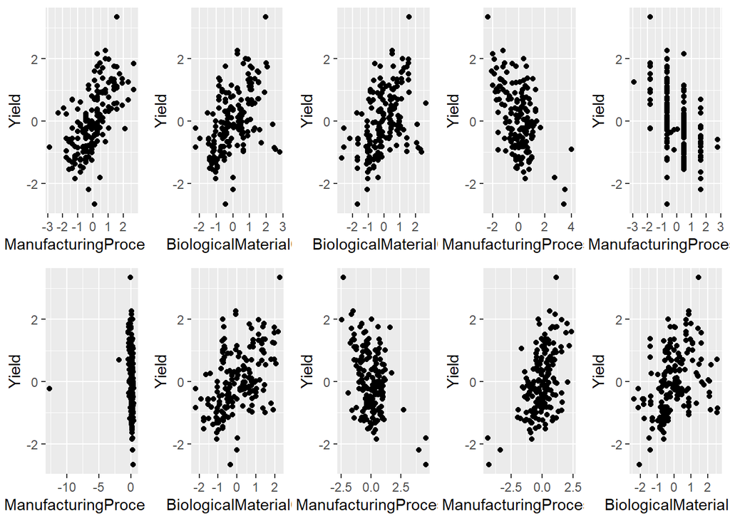

```r
p1 <- ggplot(data_imp, aes(x = ManufacturingProcess32, y = Yield)) + geom_point()
p2 <- ggplot(data_imp, aes(x = BiologicalMaterial06, y = Yield)) + geom_point()
p3 <- ggplot(data_imp, aes(x = BiologicalMaterial03, y = Yield)) + geom_point()
p4 <- ggplot(data_imp, aes(x = ManufacturingProcess13, y = Yield)) + geom_point()
p5 <- ggplot(data_imp, aes(x = ManufacturingProcess36, y = Yield)) + geom_point()
p6 <- ggplot(data_imp, aes(x = ManufacturingProcess31, y = Yield)) + geom_point()
p7 <- ggplot(data_imp, aes(x = BiologicalMaterial02, y = Yield)) + geom_point()
p8 <- ggplot(data_imp, aes(x = ManufacturingProcess17, y = Yield)) + geom_point()
p9 <- ggplot(data_imp, aes(x = ManufacturingProcess09, y = Yield)) + geom_point()
p10 <- ggplot(data_imp, aes(x = BiologicalMaterial12, y = Yield)) + geom_point()


grid.arrange(p1, p2, p3, p4, p5, p6, p7, p8, p9, p10, nrow = 2)
```

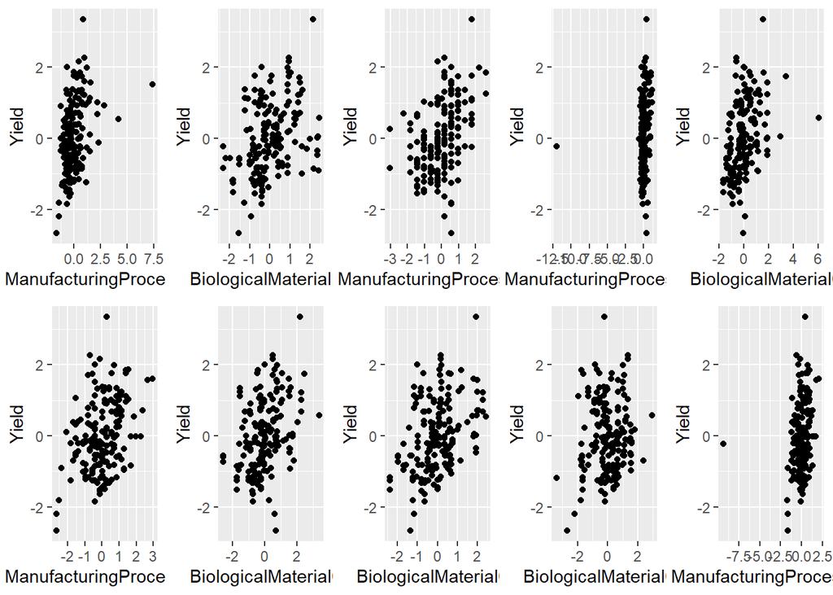

```r
p11 <- ggplot(data_imp, aes(x = ManufacturingProcess06, y = Yield)) + geom_point()
p12 <- ggplot(data_imp, aes(x = BiologicalMaterial11, y = Yield)) + geom_point()
p13 <- ggplot(data_imp, aes(x = ManufacturingProcess33, y = Yield)) + geom_point()
p14 <- ggplot(data_imp, aes(x = ManufacturingProcess29, y = Yield)) + geom_point()
p15 <- ggplot(data_imp, aes(x = BiologicalMaterial04, y = Yield)) + geom_point()
p16 <- ggplot(data_imp, aes(x = ManufacturingProcess11, y = Yield)) + geom_point()
p17 <- ggplot(data_imp, aes(x = BiologicalMaterial01, y = Yield)) + geom_point()
p18 <- ggplot(data_imp, aes(x = BiologicalMaterial08, y = Yield)) + geom_point()
p19 <- ggplot(data_imp, aes(x = BiologicalMaterial09, y = Yield)) + geom_point()
p20 <- ggplot(data_imp, aes(x = ManufacturingProcess30, y = Yield)) + geom_point()


grid.arrange(p11, p12, p13, p14, p15, p16, p17, p18, p19, p20, nrow = 2)
```

From what we can see on the plot of the first 20 important predictors and yield, some of the process variables seem to have either a positive or negative relationship as well as some that do not have a defined relationship such as in the case with process “36”, “31”, “29” and “30”. In the case of the biological variables, they all seem to have a positive relationship with yield. To answer the question above, we can say that these plots reveal intuition about the biological predictors in respect to their relationship with yield.